# Disentangle geometric and demographic fragmentation effects using spatially-explicit rarefaction curves

Felix May

2023-06-12

```r
library(spatialbiodiv)
library(tidyverse)
library(vegan)
library(scam)
library(mobr)
```

```r
knitr::opts_knit$set(root.dir = "..")
knitr::opts_chunk$set(echo = TRUE,
                      fig.width = 10)
```

# Read and prepare the data

The data used here is from a spatially-explicit metacommunity simulation model developed by Stav Gelber. From the entire simulation 30 virtual “samples” were taken from scenarios with high vs. low fragmentation but equal habitat amount.

```r
#setwd("..")
simdat1 <- read.table("data_raw/dispersal_4_rep_1_output_sample.csv", header = TRUE,
                      sep = ",")
#simdat1 <- simdat1 %>% select(-X)
```

## Filter high and low fragmentation scenarios at two different time points

Time point **t0** is directly after landscape modification happened, i.e. after certain grid cells were converted from habitat to matrix. So here, we only see what we call **geometric fragmentation effects**. At t0 all differences between high and low fragmentation scenarios can be attributed to spatial sampling only, but not to changed demographic processes in small and isolated habitat fragments.

Time point **tend** is at the end of the simulation, i.e. with long-term metacommunity dynamics in a fragmented landscape. The findings here show what we call geometric plus demographic effects.

```r
sim1 <- 1
sim2 <- 9
t0 <- 41
tend <- 100

frag_low_t0 <- simdat1 %>% filter(sim_id == sim1 & step == t0)
frag_high_t0 <- simdat1 %>% filter(sim_id == sim2 & step == t0)

frag_low_tend <- simdat1 %>% filter(sim_id == sim1 & step == tend)
frag_high_tend <- simdat1 %>%filter(sim_id == sim2 & step == tend)

nsamples <- nrow(frag_low_t0)
```

## Prepare data for spatial biodiversity curves

Get abundance tables with samples in rows and species in columns as required by **mobr**.

```r
spec_frag_low_t0 <- frag_low_t0 %>% select(sp_1:sp_1000)
spec_frag_high_t0 <- frag_high_t0 %>% select(sp_1:sp_1000)
spec_frag_low_tend <- frag_low_tend %>% select(sp_1:sp_1000)
spec_frag_high_tend <- frag_high_tend %>% select(sp_1:sp_1000)
```

Get spatial coordinates of the samples. The coordinates are the same for both time points. So they are needed only once per fragmentation scenario.

```r
xy_frag_low <-  frag_low_t0 %>%  select(loc_x, loc_y)
xy_frag_high <-  frag_high_t0 %>% select(loc_x, loc_y)
```

# Plot coordinates of the samples

```r
xy_coords <- bind_rows(xy_frag_low, xy_frag_high)
xy_coords$fragmentation <-  rep(c("Low", "High"), each = nsamples)
```

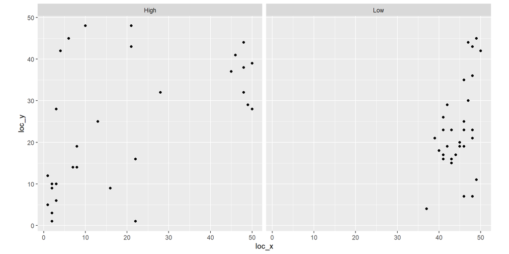

```r
ggplot(xy_coords, aes(loc_x, loc_y)) +
  geom_point() +
  facet_grid(~fragmentation) +
  coord_fixed()
```

Here we see that the samples are more spread out in the high fragmentations scenarios and thus cover a larger extent than in the low fragmentation scenario.

# Calculate non-spatial sample-based rarefaction curves (SBR)

```r
SBR_frag_low_t0 <- rarefaction(spec_frag_low_t0, method = "SBR")
SBR_frag_high_t0 <- rarefaction(spec_frag_high_t0, method = "SBR")
SBR_frag_low_tend <- rarefaction(spec_frag_low_tend, method = "SBR")
SBR_frag_high_tend <- rarefaction(spec_frag_high_tend, method = "SBR")
```

## Dataframe for plotting

```r
SBR_data <- data.frame(nsamples = rep(1:nsamples, 4),
                       S       = c(SBR_frag_low_t0,
                                   SBR_frag_high_t0,
                                   SBR_frag_low_tend,
                                   SBR_frag_high_tend),
                       fragmentation = rep(c("Low", "High","Low","High"),
                                           each = nsamples),
                       time = rep(c("t0","t0","tend","tend"),
                                  each = nsamples)
                       )
```

## Plot SBR curves

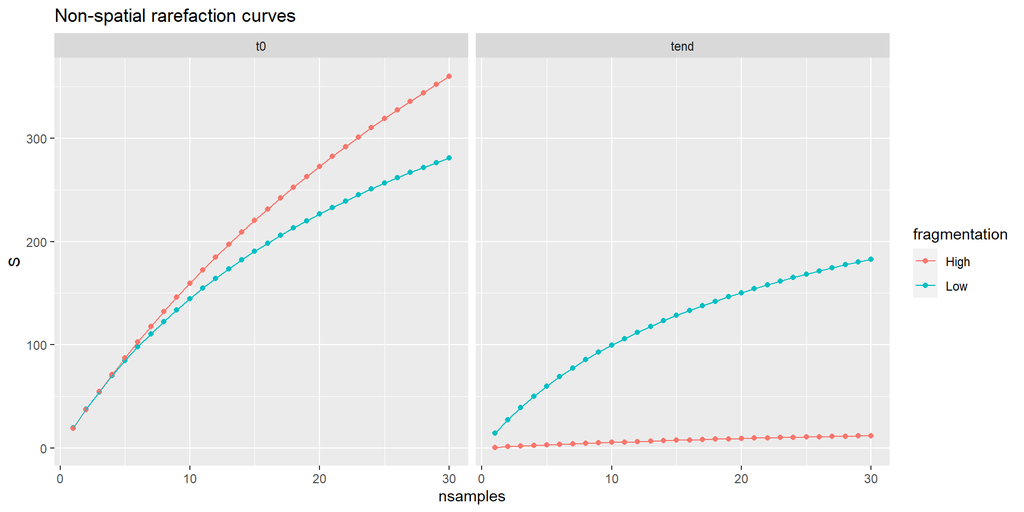

```r
ggplot(SBR_data, aes(nsamples, S, color = fragmentation)) +
  geom_point() +
  geom_line() +
  facet_grid(~time) +
  ggtitle("Non-spatial rarefaction curves")
```

In this figure we see that at **t0** a given number of samples includes much more species in the high fragmentation scenario. However at **tend** the pattern is reversed and there are much less species per equal sampling effort in the high fragmentation scenario.

Still, this analysis does not consider the higher extent sampled in the high fragmentation scenario.

# Calculate spatial rarefaction curves (sSBR)

```r
sSBR_frag_low_t0 <- rarefaction(spec_frag_low_t0, method = "sSBR", coords = xy_frag_low,
                                latlong = F, spat_algo = "kNN")

sSBR_frag_high_t0 <- rarefaction(spec_frag_high_t0, method = "sSBR", coords = xy_frag_high,
                                latlong = F, spat_algo = "kNN")

sSBR_frag_low_tend <- rarefaction(spec_frag_low_tend, method = "sSBR", coords = xy_frag_low,
                                  latlong = F, spat_algo = "kNN")

sSBR_frag_high_tend <- rarefaction(spec_frag_high_tend, method = "sSBR", coords = xy_frag_high,
                                  latlong = F, spat_algo = "kNN")
```

## Create dataframe for plotting with ggplot

```r
sSBR_data <- data.frame(nsamples = rep(1:nsamples, 4),
                        S       = c(sSBR_frag_low_t0,
                                    sSBR_frag_high_t0,
                                    sSBR_frag_low_tend,
                                    sSBR_frag_high_tend),
                        fragmentation = rep(c("Low", "High","Low","High"),
                                           each = nsamples),
                        time = rep(c("t0","t0","tend","tend"),
                                  each = nsamples)
                       )
```

### Plot the sSBR curves

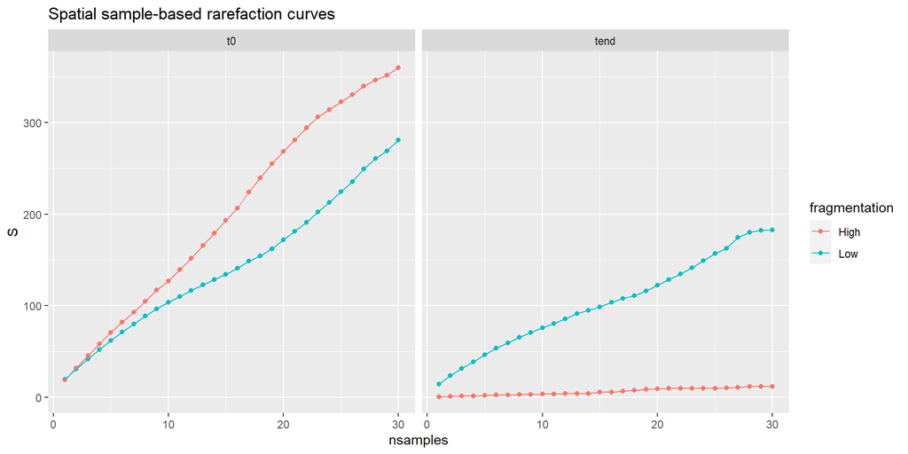

```r
ggplot(sSBR_data, aes(nsamples, S, color = fragmentation)) +
  geom_point() +
  geom_line() +
  facet_grid(~time) +
  ggtitle("Spatial sample-based rarefaction curves")
```

When we use the spatial and sample-based rarefaction curves of **mobr** the pattern remains the same as with non-spatial rarefaction curves. While these ssBR-curves accumulate samples by proximity, they still compare scenarios by sampling effort measured by no. of samples, i.e., they still do not consider the extent of a given no. of samples. For this purpose, we developed **spatially-explicit rarefaction curves** (called **spexSBR** at the moment, but this can be debated …)

# Calculate spatially explicit sample-based rarefaction curves (spexSBR)

## With convexhull-Algorithm

```r
spexSBR_frag_low_t0 <- rarefaction(spec_frag_low_t0, method = "spexSBR", coords = xy_frag_low,
                                latlong = F, spat_algo = "convexhull")

spexSBR_frag_high_t0 <- rarefaction(spec_frag_high_t0, method = "spexSBR", coords = xy_frag_high,
                                latlong = F, spat_algo = "convexhull")

spexSBR_frag_low_tend <- rarefaction(spec_frag_low_tend, method = "spexSBR", coords = xy_frag_low,
                                  latlong = F, spat_algo = "convexhull")

spexSBR_frag_high_tend <- rarefaction(spec_frag_high_tend, method = "spexSBR", coords = xy_frag_high,
                                  latlong = F, spat_algo = "convexhull")
```

### Create dataframe for plotting with ggplot

```r
spexSBR_length <- length(spexSBR_frag_low_t0)

spexSBR_data <- data.frame(area = as.numeric(c(names(spexSBR_frag_low_t0),
                                               names(spexSBR_frag_high_t0),
                                               names(spexSBR_frag_low_tend),
                                               names(spexSBR_frag_high_tend))),
                           S       = c(spexSBR_frag_low_t0,
                                       spexSBR_frag_high_t0,
                                       spexSBR_frag_low_tend,
                                       spexSBR_frag_high_tend),
                           fragmentation = rep(c("Low", "High","Low","High"),
                                         each = spexSBR_length),
                           time = rep(c("t0","t0","tend","tend"),
                                        each = spexSBR_length)
                        )
```

### Plot the spexSBR curves

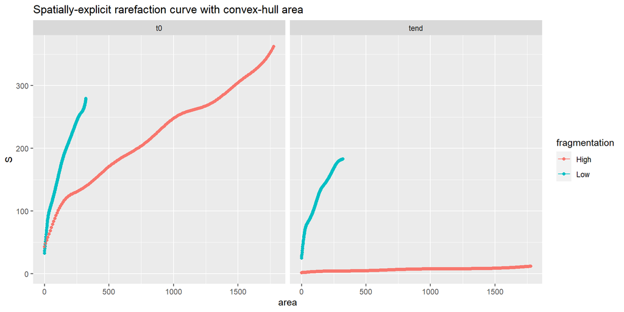

```r
ggplot(spexSBR_data, aes(area, S, color = fragmentation)) +
  geom_point() +
  geom_line() +
  facet_grid(~time) +
  ggtitle("Spatially-explicit rarefaction curve with convex-hull area")
```

Finally, we want to know if the observed differences between the spexSBR curves for the high and low fragmentation scenarios are “significant” or not. For this purpose, we use a null-model approach based on randomly permuting samples between the fragmentation scenarios.

# Calculate spexSBR differences and null-model with lower and upper bound

## Get the distance / area values from the curve with the smaller extent

Since the coordinates to not change over time, the spatial effort from just one time step is needed.

```r
spat_eff <- spexSBR_data %>%
  filter(fragmentation == "Low" & time == "t0") %>%
  select(area)
spat_eff <- as.numeric(spat_eff[[1]])
```

```r
delta_t0 <- get_spexSBR_interval(comm1 = spec_frag_low_t0, coords1 = xy_frag_low,
                                 comm2 = spec_frag_high_t0, coords2 = xy_frag_high,
                                 spat_effort = spat_eff, nperm = 30)

delta_tend <- get_spexSBR_interval(comm1 = spec_frag_low_tend, coords1 = xy_frag_low,
                                   comm2 = spec_frag_high_tend, coords2 = xy_frag_high,
                                   spat_effort = spat_eff, nperm = 30)
```

```r
delta_dat2 <- bind_rows(delta_t0, delta_tend)
delta_dat2$time <- rep(c("t0","tend"), each = length(spat_eff))
```

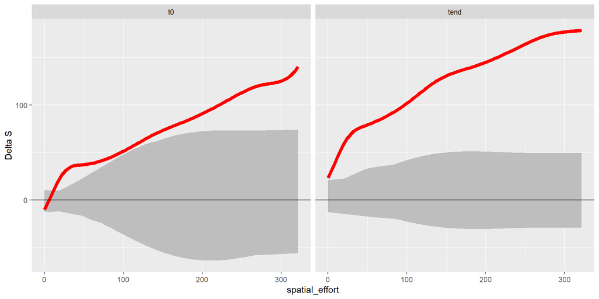

```r
ggplot(delta_dat2, aes(spatial_effort, obs)) +
  geom_ribbon(aes(ymin = lower, ymax = upper), fill = "grey") +
  geom_line(aes(y = obs),linewidth = 2, color = "red") +
  geom_hline(yintercept = 0) +
  facet_grid(~time) +
  ylab("Delta S")
```

In these figures, the red lines are the observed differences between the spexSBR curves for t0 and tend. The grey ribbons are the confidence intervals from the the null-model, where samples are randomly permuted between high and low fragmentation scenarios.